# S1.10 Code used to develop and present GLMM results

Clare Vernon

2025-03-11

#### Download files and set working directory

Set working direction and load in the files. Change the working directory as required.

Load in the relevant data file. The data file used to construct the climate and fire-related GLMM models is available here: https://github.com/ClareMVernon/ReviewShrubAlpineAustralia/blob/main/S2.4.%20Data%20of%20mean%20shrub%20cover-abundance%20used%20to%20construct%20GLMM.csv

```r
library(readr)
df_alldata <- read_csv("S2.4. Data of mean shrub cover-abundance used to construct GLMM.csv")
```

```
## ──────────────────────────────────────────────────────── Delimiter: "," chr
## (68): QualQuantInc, CADIMA Ref, Author, Study, Journal, Study ID, Fire, ... dbl
## (28): UniqueCode, PubYear, Elev_Est_Lower, Loc.y, Loc.x, Loc.y2, Loc.x2,...
```

Install packages if required.

oo <- options(repos = “https://cran.r-project.org/”) utils::install.packages(“Matrix”) utils::install.packages(“lme4”) options(oo) utils::install.packages(“https://cran.r-project.org/bin/windows/contrib/4.4/Matrix_1.7-0.zip”, repos = NULL) utils::install.packages(“https://cran.r-project.org/bin/windows/contrib/4.4/lme4_1.1-35.5.zip”, repos = NULL) install.packages(“mvabund”) install.packages(“MASS”) install.packages(“readxl”) install.packages(“ggplot2”) install.packages(“dplyr”) install.packages(“maps”) install.packages(“tidyr”) install.packages(“reshape2”) install.packages(“stringr”) install.packages(“ggrepel”) install.packages(“see”) install.packages(“devtools”) devtools::install_github(“thomasp85/patchwork”) install.packages(“PerformanceAnalytics”) install.packages(“faraway”) install.packages(“corrplot”) install.packages(c(“raster”, “terra”, “lubridate”, “patchwork”))

Load packages into the library.

```r
library(lme4)
```

```r
library(Matrix)
library(mvabund)
library(MASS)
library(readxl)
library(ggplot2)
library(dplyr)
library(maps)
library(tidyr)
library(reshape2)
library(stringr)
library(see)
library(patchwork)
library(PerformanceAnalytics)
library(raster)
library(terra)
library(lubridate)
library(patchwork)
library(faraway)
library(corrplot)
library(FSA) # required for Dunns test of significant differences
library(merDeriv)
library(parameters)
library(DHARMa)
```

#### 1. Climate GLMM Analysis

```r
df_model  <- df_alldata %>%
  filter(!is.na(StandardisedAnnualChange )) # Remove NA values
df_modela <- df_model %>% filter (Climate == "Yes")# Extracts the fire-only related rows
df_model <- df_modela %>% filter(Design == "BACI" | Design == "BA") # Omit CI designs, as this doesn't capture rate of change as t0 is not known.

df_model$StandardisedAnnualChange <- as.numeric(df_model$StandardisedAnnualChange)
df_model$color <- with(df_model, ifelse(StandardisedAnnualChange > 0, "positive", ifelse(StandardisedAnnualChange < 0, "negative", "zero")))
```

Ensure all data is correctly formatted. Note some values scaled for GLMM

```r
df_model$Year.Final <- as.numeric(df_model$Year.Final)
df_model$Year.Initial <- as.numeric(df_model$Year.Initial)
df_model$TimeSpan <- as.numeric(df_model$TimeSpan)
df_model$Elev_Est_Upper <- as.numeric(df_model$Elev_Est_Upper)
df_model$Elev_Est_Lower <- as.numeric(df_model$Elev_Est_Lower)
df_model$StandardisedAnnualChange.2<- as.numeric(df_model$StandardisedAnnualChange.2)
df_model$Elev_Est_Upper <- as.numeric(df_model$Elev_Est_Upper)
df_model$RainJan <- as.numeric(df_model$RainJan)
df_model$RainJuly<- as.numeric(df_model$RainJuly)
df_model$JanTempMax <- as.numeric(df_model$JanTempMax)
df_model$JanTempMin <- as.numeric(df_model$JanTempMin)
df_model$JulyTempMax <- as.numeric(df_model$JulyTempMax)
df_model$JulyTempMin <- as.numeric(df_model$JulyTempMin)
df_model$Elev_Est_Lowers <- scale(df_model$Elev_Est_Lower)
df_model$Elev_Est_Uppers <- scale(df_model$Elev_Est_Upper)
df_model$Year.Initial <- as.numeric(df_model$Year.Initial)
df_model$Year.Final <- as.numeric(df_model$Year.Final)
df_model$Year.Initials <- scale(df_model$Year.Initial)
df_model$Year.Finals  <- scale(df_model$Year.Final)
```

Testing whether underlying data follows a normal distribution.

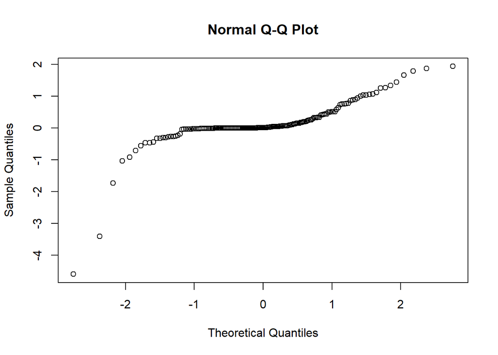

```r
qqnorm(df_model$StandardisedAnnualChange.2) # Non-linear, not a straight 45 degree line
```

```r
shapiro.test(df_model$StandardisedAnnualChange.2) # p < 0.05, non-linear
```

```
##
##  Shapiro-Wilk normality test
##
## data:  df_model$StandardisedAnnualChange.2
## W = 0.67797, p-value < 2.2e-16
```

```r
df_model$Year.Final <- as.numeric(df_model$Year.Final)
m_linear <- glmer(StandardisedAnnualChange.2 ~ Year.Final + (1 | Response.Level), data = df_model)
```

Outliers are present. Test whether removing outliers improves normal distribution.

```r
# Outliers are presented. Test whether removing outliers improves normal distribution.
df_model$StandardisedAnnualChange.2 <- as.numeric(df_model$StandardisedAnnualChange.2)
shapiro.test(df_model$StandardisedAnnualChange.2)
```

```
##
##  Shapiro-Wilk normality test
##
## data:  df_model$StandardisedAnnualChange.2
## W = 0.67797, p-value < 2.2e-16
```

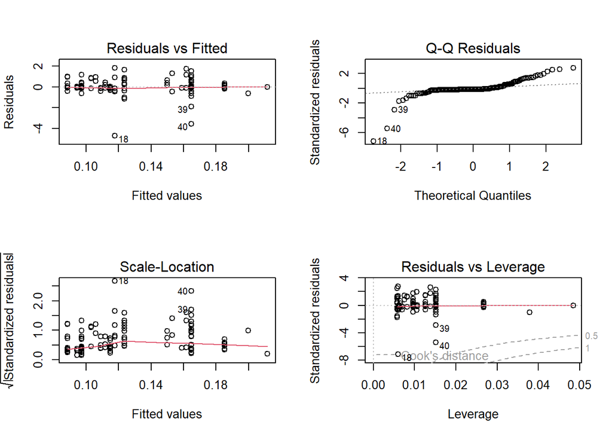

```r
# Linear model of all data
lm.test.normalresid <- lm(StandardisedAnnualChange.2 ~ Year.Final, data = df_model)
par(mfrow = c(2, 2))
plot(lm.test.normalresid)
```

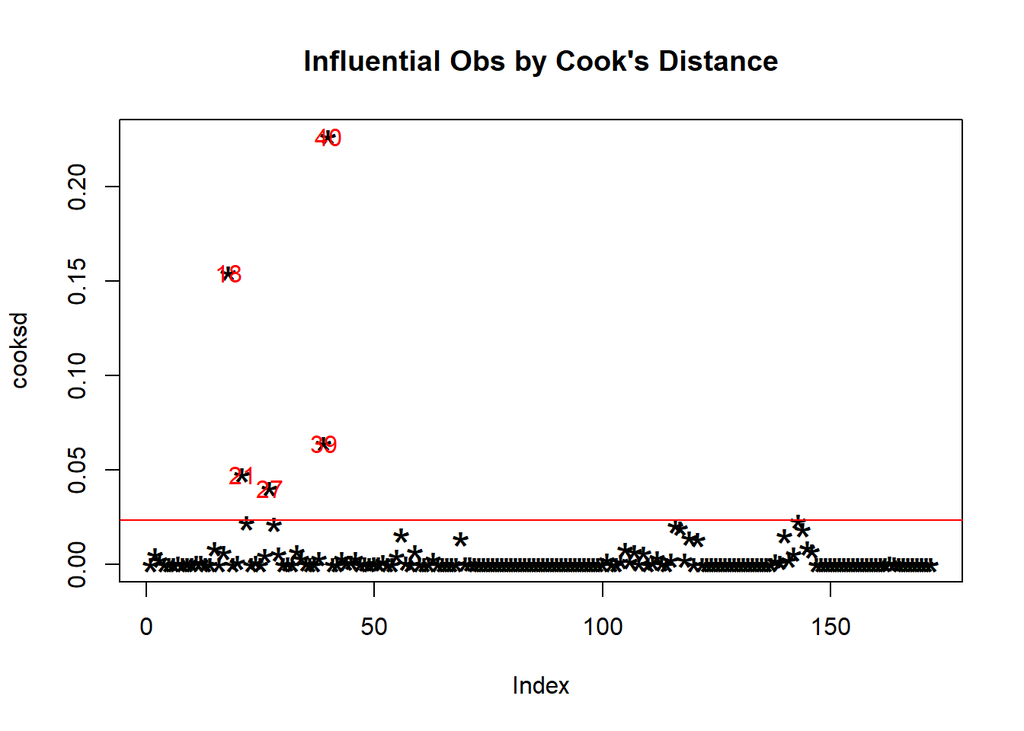

```r
par(mfrow = c(1, 1))
cooksd <- cooks.distance(lm.test.normalresid)
sample_size <- nrow(df_model)
plot(cooksd, pch = "*", cex = 2, main = "Influential Obs by Cook's Distance")
abline(h = 4/sample_size, col = "red")  # Add cutoff line
text(x = seq_along(cooksd), y = cooksd, labels = ifelse(cooksd > 4/sample_size, seq_along(cooksd), ""), col = "red")
```

```r
influential <- which(cooksd > (4/sample_size))

# Create a new dataframe without outliers
df_model_no_outlier <- df_model[-influential, ]
head(df_model_no_outlier)
```

```
## # A tibble: 6 × 101
##   UniqueCode QualQuantInc `CADIMA Ref` Author   Study PubYear Journal `Study ID`
##        <dbl> <chr>        <chr>        <chr>    <chr>   <dbl> <chr>   <chr>
## 1          5 Quant+Qual   18           McDouga… McDo…    2013 <NA>    AlpineRd
## 2         44 Quant+Qual   44           Wahren … Wahr…    2013 Austra… ITEX
## 3         46 Quant+Qual   44           Wahren … Wahr…    2013 Austra… ITEX
## 4         52 Quant+Qual   44           Wahren … Wahr…    2013 Austra… LongTerm
## 5         53 Quant+Qual   44           Wahren … Wahr…    2013 Austra… LongTerm
## 6         54 Quant+Qual   44           Wahren … Wahr…    2013 Austra… LongTerm
## # ℹ 93 more variables: Fire <chr>, Grazing <chr>, Tourism <chr>,
## #   Elevation_Stated <chr>, Elevation_Est <chr>, Elev_Est_Lower <dbl>,
## #   Elev_Est_Upper <dbl>, Slope <chr>, Slope_New <chr>, Landform <chr>,
## #   Landform_Analysis <chr>, Aspect <chr>, Temperature <chr>, Rainfall <chr>,
## #   Snow <chr>, `Bare ground` <chr>, Studysite <chr>, Loc.y <dbl>, Loc.x <dbl>,
## #   Studysite.aggregate <chr>, StudySite.LatLong <chr>, Loc.y2 <dbl>,
## #   Loc.x2 <dbl>, Studysite.aggregate.2 <chr>, Loc.y.2 <dbl>, Loc.x.2 <dbl>, …
```

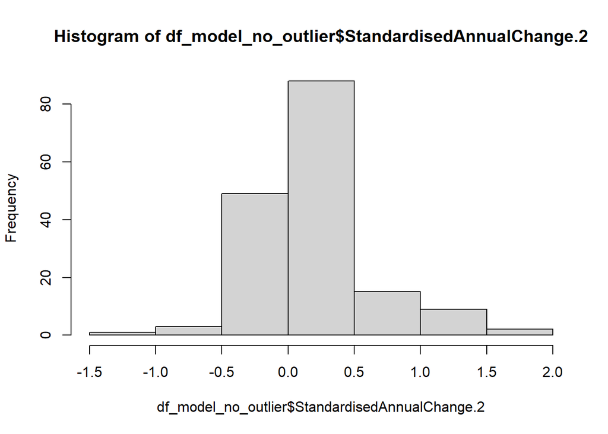

```r
hist(df_model_no_outlier$StandardisedAnnualChange.2)
```

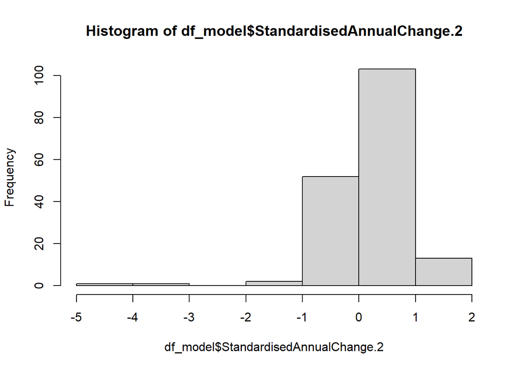

```r
hist(df_model$StandardisedAnnualChange.2)
```

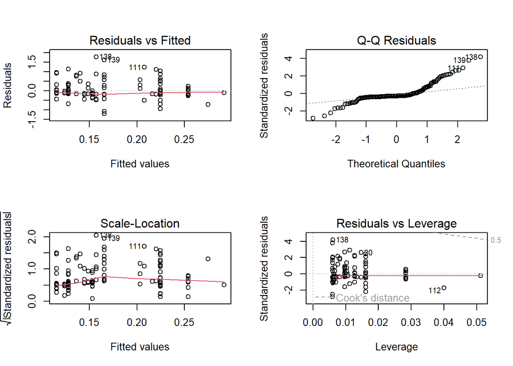

```r
lm.test.normalresid <- lm(StandardisedAnnualChange.2 ~ Year.Final, data = df_model_no_outlier)
par(mfrow = c(2, 2))
plot(lm.test.normalresid ) # Look at the results
```

```r
par(mfrow = c(1,1))

# Does the normality improve if outliers are removed?
shapiro.test(df_model$StandardisedAnnualChange.2) # p < 0.05
```

```
##
##  Shapiro-Wilk normality test
##
## data:  df_model$StandardisedAnnualChange.2
## W = 0.67797, p-value < 2.2e-16
```

```r
shapiro.test(df_model_no_outlier$StandardisedAnnualChange) # p < 0.05
```

```
##
##  Shapiro-Wilk normality test
##
## data:  df_model_no_outlier$StandardisedAnnualChange
## W = 0.81959, p-value = 4.332e-13
```

**Outcome:** No significant improvement, p << 0.001 for both models. Retain all datasets to better represent fire responses of shrubs.

**Assess correlations:** highly correlated variables (r > 0.70) are to be excluded from the same model as model terms.

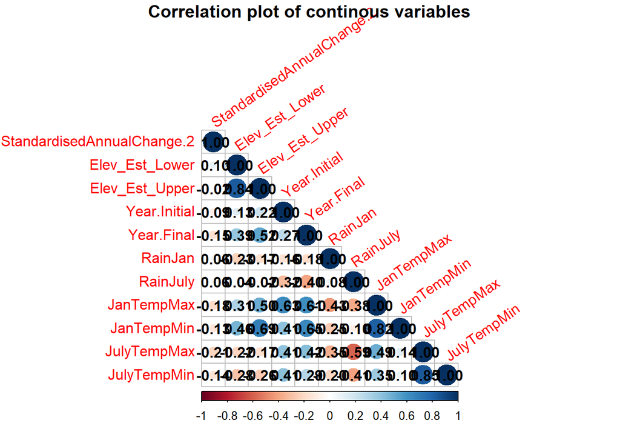

```r
subset_corrdata <- df_model[, c("StandardisedAnnualChange.2",
                                "Elev_Est_Lower",
                                "Elev_Est_Upper",
                                "Year.Initial",
                                "Year.Final",
                                "RainJan",
                                "RainJuly",
                                "JanTempMax",
                                "JanTempMin",
                                "JulyTempMax",
                                "JulyTempMin")]
res <- cor(subset_corrdata, method = c("spearman"))
corrplot(res, tl.col = "red", bg = "White", tl.srt = 35,
         title = "\n\n Correlation plot of continous variables \n",
         addCoef.col = "black", type = "lower") # Show correlation strengths. Same plot shown in S3 with relabelled variables for clarity.
```

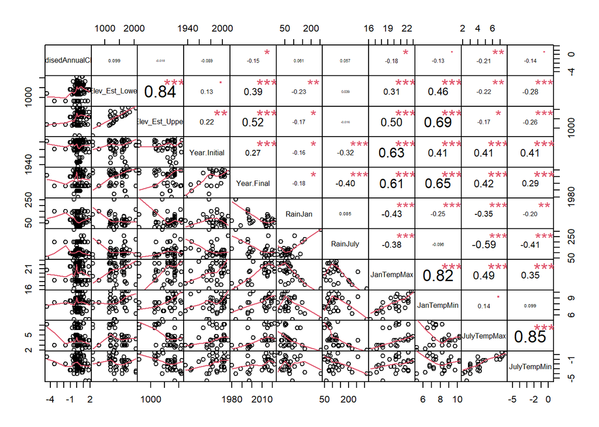

```r
p_corrchart <- chart.Correlation(subset_corrdata[,1:11], histogram=FALSE, method = c("spearman"), pch="19", exact = FALSE)
```

```r
p_corrchart # Alternative correlation plot showing the significance and distribution of data.
```

**Assessing whether data differs based on study characteristics:** we used the Kruskal-Wallis test to examine whether the annual change in cover-abundance significantly differed between population scales, alpine zones of shrub species and ecosystem types. If p < 0.05, we used Dunn’s test to undertake pairwise comparisions.

```r
# Population Scale
kruskal.test(StandardisedAnnualChange.2 ~ Response.Level, data = df_model)
```

```
##
##  Kruskal-Wallis rank sum test
##
## data:  StandardisedAnnualChange.2 by Response.Level
## Kruskal-Wallis chi-squared = 7.7965, df = 2, p-value = 0.02028
```

```r
# Alpine zone of shrub species
kruskal.test(StandardisedAnnualChange.2 ~ Alpine.Zone, data = df_model)
```

```
##
##  Kruskal-Wallis rank sum test
##
## data:  StandardisedAnnualChange.2 by Alpine.Zone
## Kruskal-Wallis chi-squared = 7.3102, df = 3, p-value = 0.06264
```

```r
# Ecosystem type
kruskal.test(StandardisedAnnualChange.2 ~ Aggregate.InitialES, data = df_model)
```

```
##
##  Kruskal-Wallis rank sum test
##
## data:  StandardisedAnnualChange.2 by Aggregate.InitialES
## Kruskal-Wallis chi-squared = 16.271, df = 6, p-value = 0.01237
```

```r
dunnTest(StandardisedAnnualChange.2 ~ Aggregate.InitialES, data = df_model, method="bh")
```

```
## Dunn (1964) Kruskal-Wallis multiple comparison
```

```
##   p-values adjusted with the Benjamini-Hochberg method.
```

```
##                                                      Comparison          Z
## 1  Cushion heathland / Fjaledmark - Grassland (dry) / Herbfield -0.7213766
## 2              Cushion heathland / Fjaledmark - Heathland (dry) -1.5896211
## 3                 Grassland (dry) / Herbfield - Heathland (dry) -0.9822399
## 4  Cushion heathland / Fjaledmark - Heathland (dry) / Grassland -1.3653456
## 5     Grassland (dry) / Herbfield - Heathland (dry) / Grassland -0.6304616
## 6                 Heathland (dry) - Heathland (dry) / Grassland  0.5456626
## 7              Cushion heathland / Fjaledmark - Heathland (wet) -0.8868879
## 8                 Grassland (dry) / Herbfield - Heathland (wet) -0.4654423
## 9                             Heathland (dry) - Heathland (wet)  0.1037610
## 10                Heathland (dry) / Grassland - Heathland (wet) -0.1731598
## 11                    Cushion heathland / Fjaledmark - Multiple  1.5119970
## 12                       Grassland (dry) / Herbfield - Multiple  2.4354700
## 13                                   Heathland (dry) - Multiple  3.3116348
## 14                       Heathland (dry) / Grassland - Multiple  3.4141061
```

[output cut: 29 more lines]

**Testing model requirement:**

1. That > 10-20 samples per treatment - this is met as all samples have temperature, rainfall and final sampling year.
2. That categorical variables have at least six levels. See code below.

```r
n_distinct(df_model$Study) # > 6
```

```
## [1] 26
```

```r
n_distinct(df_model$Studysite) # > 6
```

```
## [1] 24
```

```r
n_distinct(df_model$Response.Level) # < 6 levels, omit
```

```
## [1] 3
```

#### 1.1. Development of Full Climate Model

```r
# Null model
m.null <- glmer(StandardisedAnnualChange.2 ~ (1 | Study) + (1 | Studysite) + (1 | Year.Finals) + (1 | Elev_Est_Lower), data = df_model)
```

```
## boundary (singular) fit: see help('isSingular')
```

```r
summary(m.null)
```

```
## Linear mixed model fit by REML ['lmerMod']
## Formula: StandardisedAnnualChange.2 ~ (1 | Study) + (1 | Studysite) +
##     (1 | Year.Finals) + (1 | Elev_Est_Lower)
##    Data: df_model
##
## REML criterion at convergence: 332.1
##
## Scaled residuals:
##     Min      1Q  Median      3Q     Max
## -5.8635 -0.1916 -0.0881  0.1623  2.9067
##
## Random effects:
##  Groups         Name        Variance  Std.Dev.
##  Study          (Intercept) 1.968e-03 4.437e-02
##  Studysite      (Intercept) 2.977e-01 5.456e-01
##  Elev_Est_Lower (Intercept) 8.710e-11 9.333e-06
##  Year.Finals    (Intercept) 4.685e-02 2.165e-01
##  Residual                   3.069e-01 5.540e-01
## Number of obs: 172, groups:
## Study, 26; Studysite, 24; Elev_Est_Lower, 19; Year.Finals, 18
##
## Fixed effects:
##             Estimate Std. Error t value
## (Intercept)   0.1989     0.1448   1.373
## optimizer (nloptwrap) convergence code: 0 (OK)
## boundary (singular) fit: see help('isSingular')
```

```r
AIC(m.null)
```

```
## [1] 344.0508
```

```r
# Overfitted model
m.overfit <- glmer(StandardisedAnnualChange.2 ~ JanTempMax + JulyTempMin + RainJan + RainJuly + (1 | Year.Finals) + (1 | Study) + (1 | Studysite) + (1 | Elev_Est_Lower), data = df_model)
```

```
## boundary (singular) fit: see help('isSingular')
```

```r
summary(m.overfit) # REML = 357.2
```

```
## Linear mixed model fit by REML ['lmerMod']
## Formula: StandardisedAnnualChange.2 ~ JanTempMax + JulyTempMin + RainJan +
##     RainJuly + (1 | Year.Finals) + (1 | Study) + (1 | Studysite) +
##     (1 | Elev_Est_Lower)
##    Data: df_model
##
## REML criterion at convergence: 357.2
##
## Scaled residuals:
##     Min      1Q  Median      3Q     Max
## -5.6773 -0.1858 -0.0710  0.1280  2.9201
##
## Random effects:
##  Groups         Name        Variance Std.Dev.
##  Study          (Intercept) 0.005701 0.0755
##  Studysite      (Intercept) 0.317726 0.5637
##  Elev_Est_Lower (Intercept) 0.000000 0.0000
##  Year.Finals    (Intercept) 0.084196 0.2902
##  Residual                   0.298679 0.5465
## Number of obs: 172, groups:
## Study, 26; Studysite, 24; Elev_Est_Lower, 19; Year.Finals, 18
##
## Fixed effects:
##              Estimate Std. Error t value
## (Intercept)  0.296767   1.725351   0.172
## JanTempMax  -0.005783   0.074802  -0.077
## JulyTempMin -0.092981   0.085538  -1.087
## RainJan     -0.003447   0.002768  -1.245
## RainJuly     0.001219   0.001982   0.615
##
## Correlation of Fixed Effects:
##             (Intr) JnTmpM JlyTmM RainJn
## JanTempMax  -0.986
## JulyTempMin  0.305 -0.253
## RainJan     -0.384  0.340  0.079
## RainJuly    -0.476  0.419 -0.071 -0.198
## optimizer (nloptwrap) convergence code: 0 (OK)
## boundary (singular) fit: see help('isSingular')
```

```r
AIC(m.overfit)
```

```
## [1] 377.2328
```

```r
# Test REML of all possible model combinations
m.x <- glmer(StandardisedAnnualChange.2 ~ JanTempMax + JulyTempMin + RainJan + RainJuly + (1 | Year.Finals) + (1 | Study) + (1 | Studysite) + (1 | Elev_Est_Lower), data = df_model)
```

```
## boundary (singular) fit: see help('isSingular')
```

```r
summary(m.x)
```

```
## Linear mixed model fit by REML ['lmerMod']
## Formula: StandardisedAnnualChange.2 ~ JanTempMax + JulyTempMin + RainJan +
##     RainJuly + (1 | Year.Finals) + (1 | Study) + (1 | Studysite) +
##     (1 | Elev_Est_Lower)
##    Data: df_model
##
## REML criterion at convergence: 357.2
##
## Scaled residuals:
##     Min      1Q  Median      3Q     Max
## -5.6773 -0.1858 -0.0710  0.1280  2.9201
##
## Random effects:
##  Groups         Name        Variance Std.Dev.
##  Study          (Intercept) 0.005701 0.0755
##  Studysite      (Intercept) 0.317726 0.5637
##  Elev_Est_Lower (Intercept) 0.000000 0.0000
##  Year.Finals    (Intercept) 0.084196 0.2902
##  Residual                   0.298679 0.5465
## Number of obs: 172, groups:
## Study, 26; Studysite, 24; Elev_Est_Lower, 19; Year.Finals, 18
##
## Fixed effects:
##              Estimate Std. Error t value
## (Intercept)  0.296767   1.725351   0.172
## JanTempMax  -0.005783   0.074802  -0.077
## JulyTempMin -0.092981   0.085538  -1.087
## RainJan     -0.003447   0.002768  -1.245
## RainJuly     0.001219   0.001982   0.615
##
## Correlation of Fixed Effects:
##             (Intr) JnTmpM JlyTmM RainJn
## JanTempMax  -0.986
## JulyTempMin  0.305 -0.253
## RainJan     -0.384  0.340  0.079
## RainJuly    -0.476  0.419 -0.071 -0.198
## optimizer (nloptwrap) convergence code: 0 (OK)
## boundary (singular) fit: see help('isSingular')
```

```r
m.x <- glmer(StandardisedAnnualChange.2 ~ JanTempMax + JulyTempMin + RainJan + RainJuly + (1 | Study), data = df_model)
summary(m.x)
```

```
## Linear mixed model fit by REML ['lmerMod']
## Formula: StandardisedAnnualChange.2 ~ JanTempMax + JulyTempMin + RainJan +
##     RainJuly + (1 | Study)
##    Data: df_model
##
## REML criterion at convergence: 369.8
##
## Scaled residuals:
##    Min     1Q Median     3Q    Max
## -6.153 -0.204 -0.021  0.232  2.817
##
## Random effects:
##  Groups   Name        Variance Std.Dev.
##  Study    (Intercept) 0.1105   0.3324
##  Residual             0.3742   0.6117
## Number of obs: 172, groups:  Study, 26
##
## Fixed effects:
##              Estimate Std. Error t value
## (Intercept)  0.709925   1.314485   0.540
## JanTempMax  -0.035584   0.054923  -0.648
## JulyTempMin -0.106570   0.065503  -1.627
## RainJan     -0.002827   0.002244  -1.260
## RainJuly     0.001563   0.001680   0.930
##
## Correlation of Fixed Effects:
##             (Intr) JnTmpM JlyTmM RainJn
## JanTempMax  -0.987
## JulyTempMin  0.267 -0.209
## RainJan     -0.501  0.488  0.091
## RainJuly    -0.396  0.316 -0.032 -0.238
```

```r
m.x <- glmer(StandardisedAnnualChange.2 ~ JanTempMax + JulyTempMin + RainJan + RainJuly + (1 | Year.Finals), data = df_model)
```

```
## boundary (singular) fit: see help('isSingular')
```

```r
summary(m.x)
```

```
## Linear mixed model fit by REML ['lmerMod']
## Formula: StandardisedAnnualChange.2 ~ JanTempMax + JulyTempMin + RainJan +
##     RainJuly + (1 | Year.Finals)
##    Data: df_model
##
## REML criterion at convergence: 372.6
##
## Scaled residuals:
##     Min      1Q  Median      3Q     Max
## -7.0904 -0.2475 -0.0777  0.2201  2.5567
##
## Random effects:
##  Groups      Name        Variance Std.Dev.
##  Year.Finals (Intercept) 0.0000   0.0000
##  Residual                0.4254   0.6522
## Number of obs: 172, groups:  Year.Finals, 18
##
## Fixed effects:
##               Estimate Std. Error t value
## (Intercept)  0.5663671  0.9301204   0.609
## JanTempMax  -0.0236785  0.0376969  -0.628
## JulyTempMin -0.1238809  0.0492451  -2.516
## RainJan     -0.0012539  0.0014809  -0.847
## RainJuly    -0.0006377  0.0012862  -0.496
##
## Correlation of Fixed Effects:
##             (Intr) JnTmpM JlyTmM RainJn
## JanTempMax  -0.987
## JulyTempMin  0.212 -0.170
## RainJan     -0.544  0.512 -0.077
## RainJuly    -0.496  0.417  0.196 -0.057
## optimizer (nloptwrap) convergence code: 0 (OK)
## boundary (singular) fit: see help('isSingular')
```

```r
m.x <- glmer(StandardisedAnnualChange.2 ~ JanTempMax + JulyTempMin + RainJan + RainJuly + (1 | Studysite), data = df_model)
summary(m.x)
```

```
## Linear mixed model fit by REML ['lmerMod']
## Formula: StandardisedAnnualChange.2 ~ JanTempMax + JulyTempMin + RainJan +
##     RainJuly + (1 | Studysite)
##    Data: df_model
##
## REML criterion at convergence: 358.4
##
## Scaled residuals:
##     Min      1Q  Median      3Q     Max
## -5.9438 -0.1956 -0.1194  0.1920  2.7447
##
## Random effects:
##  Groups    Name        Variance Std.Dev.
##  Studysite (Intercept) 0.2570   0.507
##  Residual              0.3306   0.575
## Number of obs: 172, groups:  Studysite, 24
##
## Fixed effects:
##              Estimate Std. Error t value
## (Intercept) -0.641435   1.327006  -0.483
## JanTempMax   0.030013   0.055126   0.544
## JulyTempMin -0.128045   0.064122  -1.997
## RainJan     -0.001603   0.001958  -0.818
## RainJuly     0.001011   0.001654   0.611
##
## Correlation of Fixed Effects:
##             (Intr) JnTmpM JlyTmM RainJn
## JanTempMax  -0.987
## JulyTempMin  0.401 -0.359
## RainJan     -0.516  0.494  0.006
## RainJuly    -0.572  0.513 -0.194 -0.105
```

```r
m.x <- glmer(StandardisedAnnualChange.2 ~ JanTempMax + JulyTempMin + RainJan + RainJuly + (1 | Elev_Est_Lower), data = df_model)
```

```
## boundary (singular) fit: see help('isSingular')
```

```r
summary(m.x)
```

```
## Linear mixed model fit by REML ['lmerMod']
## Formula: StandardisedAnnualChange.2 ~ JanTempMax + JulyTempMin + RainJan +
##     RainJuly + (1 | Elev_Est_Lower)
##    Data: df_model
##
## REML criterion at convergence: 372.6
##
## Scaled residuals:
##     Min      1Q  Median      3Q     Max
## -7.0904 -0.2475 -0.0777  0.2201  2.5567
##
## Random effects:
##  Groups         Name        Variance Std.Dev.
##  Elev_Est_Lower (Intercept) 0.0000   0.0000
##  Residual                   0.4254   0.6522
## Number of obs: 172, groups:  Elev_Est_Lower, 19
##
## Fixed effects:
##               Estimate Std. Error t value
## (Intercept)  0.5663671  0.9301204   0.609
## JanTempMax  -0.0236785  0.0376969  -0.628
## JulyTempMin -0.1238809  0.0492451  -2.516
## RainJan     -0.0012539  0.0014809  -0.847
## RainJuly    -0.0006377  0.0012862  -0.496
##
## Correlation of Fixed Effects:
##             (Intr) JnTmpM JlyTmM RainJn
## JanTempMax  -0.987
## JulyTempMin  0.212 -0.170
## RainJan     -0.544  0.512 -0.077
## RainJuly    -0.496  0.417  0.196 -0.057
## optimizer (nloptwrap) convergence code: 0 (OK)
## boundary (singular) fit: see help('isSingular')
```

```r
m.x <- glmer(StandardisedAnnualChange.2 ~ JanTempMax + JulyTempMin + RainJan + RainJuly + (1 | Year.Finals) + (1 | Study), data = df_model)
```

```
## boundary (singular) fit: see help('isSingular')
```

```r
summary(m.x)
```

```
## Linear mixed model fit by REML ['lmerMod']
## Formula: StandardisedAnnualChange.2 ~ JanTempMax + JulyTempMin + RainJan +
##     RainJuly + (1 | Year.Finals) + (1 | Study)
##    Data: df_model
##
## REML criterion at convergence: 369.8
##
## Scaled residuals:
##    Min     1Q Median     3Q    Max
## -6.153 -0.204 -0.021  0.232  2.817
##
## Random effects:
##  Groups      Name        Variance Std.Dev.
##  Study       (Intercept) 0.1105   0.3324
##  Year.Finals (Intercept) 0.0000   0.0000
##  Residual                0.3742   0.6117
## Number of obs: 172, groups:  Study, 26; Year.Finals, 18
##
## Fixed effects:
##              Estimate Std. Error t value
## (Intercept)  0.709925   1.314485   0.540
## JanTempMax  -0.035584   0.054923  -0.648
## JulyTempMin -0.106570   0.065503  -1.627
## RainJan     -0.002827   0.002244  -1.260
## RainJuly     0.001563   0.001680   0.930
##
## Correlation of Fixed Effects:
##             (Intr) JnTmpM JlyTmM RainJn
## JanTempMax  -0.987
## JulyTempMin  0.267 -0.209
## RainJan     -0.501  0.488  0.091
## RainJuly    -0.396  0.316 -0.032 -0.238
## optimizer (nloptwrap) convergence code: 0 (OK)
## boundary (singular) fit: see help('isSingular')
```

```r
m.x <- glmer(StandardisedAnnualChange.2 ~ JanTempMax + JulyTempMin + RainJan + RainJuly + (1 | Year.Finals) + (1 | Studysite), data = df_model)
summary(m.x)
```

```
## Linear mixed model fit by REML ['lmerMod']
## Formula: StandardisedAnnualChange.2 ~ JanTempMax + JulyTempMin + RainJan +
##     RainJuly + (1 | Year.Finals) + (1 | Studysite)
##    Data: df_model
##
## REML criterion at convergence: 357.3
##
## Scaled residuals:
##     Min      1Q  Median      3Q     Max
## -5.6774 -0.1823 -0.0559  0.1301  2.9147
##
## Random effects:
##  Groups      Name        Variance Std.Dev.
##  Studysite   (Intercept) 0.31925  0.5650
##  Year.Finals (Intercept) 0.08315  0.2884
##  Residual                0.30075  0.5484
## Number of obs: 172, groups:  Studysite, 24; Year.Finals, 18
##
## Fixed effects:
##              Estimate Std. Error t value
## (Intercept)  0.314273   1.708693   0.184
## JanTempMax  -0.006039   0.074077  -0.082
## JulyTempMin -0.093442   0.084885  -1.101
## RainJan     -0.003442   0.002741  -1.256
## RainJuly     0.001104   0.001965   0.562
##
## Correlation of Fixed Effects:
##             (Intr) JnTmpM JlyTmM RainJn
## JanTempMax  -0.986
## JulyTempMin  0.305 -0.254
## RainJan     -0.382  0.337  0.077
## RainJuly    -0.480  0.424 -0.068 -0.195
```

```r
m.x <- glmer(StandardisedAnnualChange.2 ~ JanTempMax + JulyTempMin + RainJan + RainJuly + (1 | Year.Finals) + (1 | Elev_Est_Lower), data = df_model)
```

```
## boundary (singular) fit: see help('isSingular')
```

```r
summary(m.x)
```

```
## Linear mixed model fit by REML ['lmerMod']
## Formula: StandardisedAnnualChange.2 ~ JanTempMax + JulyTempMin + RainJan +
##     RainJuly + (1 | Year.Finals) + (1 | Elev_Est_Lower)
##    Data: df_model
##
## REML criterion at convergence: 372.6
##
## Scaled residuals:
##     Min      1Q  Median      3Q     Max
## -7.0904 -0.2475 -0.0777  0.2201  2.5567
##
## Random effects:
##  Groups         Name        Variance Std.Dev.
##  Elev_Est_Lower (Intercept) 0.0000   0.0000
##  Year.Finals    (Intercept) 0.0000   0.0000
##  Residual                   0.4254   0.6522
## Number of obs: 172, groups:  Elev_Est_Lower, 19; Year.Finals, 18
##
## Fixed effects:
##               Estimate Std. Error t value
## (Intercept)  0.5663671  0.9301204   0.609
## JanTempMax  -0.0236785  0.0376969  -0.628
## JulyTempMin -0.1238809  0.0492451  -2.516
## RainJan     -0.0012539  0.0014809  -0.847
## RainJuly    -0.0006377  0.0012862  -0.496
##
## Correlation of Fixed Effects:
##             (Intr) JnTmpM JlyTmM RainJn
## JanTempMax  -0.987
## JulyTempMin  0.212 -0.170
## RainJan     -0.544  0.512 -0.077
## RainJuly    -0.496  0.417  0.196 -0.057
## optimizer (nloptwrap) convergence code: 0 (OK)
## boundary (singular) fit: see help('isSingular')
```

```r
m.x <- glmer(StandardisedAnnualChange.2 ~ JanTempMax + JulyTempMin + RainJan + RainJuly + (1 | Study) + (1 | Studysite), data = df_model)
summary(m.x)
```

```
## Linear mixed model fit by REML ['lmerMod']
## Formula: StandardisedAnnualChange.2 ~ JanTempMax + JulyTempMin + RainJan +
##     RainJuly + (1 | Study) + (1 | Studysite)
##    Data: df_model
##
## REML criterion at convergence: 358.4
##
## Scaled residuals:
##     Min      1Q  Median      3Q     Max
## -5.9447 -0.1878 -0.1179  0.1819  2.7539
##
## Random effects:
##  Groups    Name        Variance Std.Dev.
##  Study     (Intercept) 0.004372 0.06612
##  Studysite (Intercept) 0.257000 0.50695
##  Residual              0.328301 0.57298
## Number of obs: 172, groups:  Study, 26; Studysite, 24
##
## Fixed effects:
##              Estimate Std. Error t value
## (Intercept) -0.634248   1.341526  -0.473
## JanTempMax   0.029244   0.055794   0.524
## JulyTempMin -0.125984   0.065095  -1.935
## RainJan     -0.001697   0.001996  -0.850
## RainJuly     0.001178   0.001671   0.705
##
## Correlation of Fixed Effects:
##             (Intr) JnTmpM JlyTmM RainJn
## JanTempMax  -0.987
## JulyTempMin  0.397 -0.354
## RainJan     -0.515  0.493  0.005
## RainJuly    -0.561  0.502 -0.189 -0.119
```

```r
m.x <- glmer(StandardisedAnnualChange.2 ~ JanTempMax + JulyTempMin + RainJan + RainJuly + (1 | Studysite) + (1 | Elev_Est_Lower), data = df_model)
```

```
## boundary (singular) fit: see help('isSingular')
```

```r
summary(m.x)
```

```
## Linear mixed model fit by REML ['lmerMod']
## Formula: StandardisedAnnualChange.2 ~ JanTempMax + JulyTempMin + RainJan +
##     RainJuly + (1 | Studysite) + (1 | Elev_Est_Lower)
##    Data: df_model
##
## REML criterion at convergence: 358.4
##
## Scaled residuals:
##     Min      1Q  Median      3Q     Max
## -5.9438 -0.1956 -0.1194  0.1920  2.7447
##
## Random effects:
##  Groups         Name        Variance Std.Dev.
##  Studysite      (Intercept) 0.2570   0.507
##  Elev_Est_Lower (Intercept) 0.0000   0.000
##  Residual                   0.3306   0.575
## Number of obs: 172, groups:  Studysite, 24; Elev_Est_Lower, 19
##
## Fixed effects:
##              Estimate Std. Error t value
## (Intercept) -0.641433   1.327005  -0.483
## JanTempMax   0.030013   0.055126   0.544
## JulyTempMin -0.128045   0.064122  -1.997
## RainJan     -0.001603   0.001958  -0.818
## RainJuly     0.001011   0.001654   0.611
##
## Correlation of Fixed Effects:
##             (Intr) JnTmpM JlyTmM RainJn
## JanTempMax  -0.987
## JulyTempMin  0.401 -0.359
## RainJan     -0.516  0.494  0.006
## RainJuly    -0.572  0.513 -0.194 -0.105
## optimizer (nloptwrap) convergence code: 0 (OK)
## boundary (singular) fit: see help('isSingular')
```

```r
m.x <- glmer(StandardisedAnnualChange.2 ~ JanTempMax + JulyTempMin + RainJan + RainJuly + (1 | Study) + (1 | Elev_Est_Lower), data = df_model)
```

```
## boundary (singular) fit: see help('isSingular')
```

```r
summary(m.x)
```

```
## Linear mixed model fit by REML ['lmerMod']
## Formula: StandardisedAnnualChange.2 ~ JanTempMax + JulyTempMin + RainJan +
##     RainJuly + (1 | Study) + (1 | Elev_Est_Lower)
##    Data: df_model
##
## REML criterion at convergence: 369.8
##
## Scaled residuals:
##    Min     1Q Median     3Q    Max
## -6.153 -0.204 -0.021  0.232  2.817
##
## Random effects:
##  Groups         Name        Variance Std.Dev.
##  Study          (Intercept) 0.1105   0.3324
##  Elev_Est_Lower (Intercept) 0.0000   0.0000
##  Residual                   0.3742   0.6117
## Number of obs: 172, groups:  Study, 26; Elev_Est_Lower, 19
##
## Fixed effects:
##              Estimate Std. Error t value
## (Intercept)  0.709925   1.314485   0.540
## JanTempMax  -0.035584   0.054923  -0.648
## JulyTempMin -0.106570   0.065503  -1.627
## RainJan     -0.002827   0.002244  -1.260
## RainJuly     0.001563   0.001680   0.930
##
## Correlation of Fixed Effects:
##             (Intr) JnTmpM JlyTmM RainJn
## JanTempMax  -0.987
## JulyTempMin  0.267 -0.209
## RainJan     -0.501  0.488  0.091
## RainJuly    -0.396  0.316 -0.032 -0.238
## optimizer (nloptwrap) convergence code: 0 (OK)
## boundary (singular) fit: see help('isSingular')
```

```r
m.x <- glmer(StandardisedAnnualChange.2 ~ JanTempMax + JulyTempMin + RainJan + RainJuly + (1 | Year.Finals)+ (1 | Studysite) + (1 | Elev_Est_Lower), data = df_model)
```

```
## boundary (singular) fit: see help('isSingular')
```

```r
summary(m.x)
```

```
## Linear mixed model fit by REML ['lmerMod']
## Formula: StandardisedAnnualChange.2 ~ JanTempMax + JulyTempMin + RainJan +
##     RainJuly + (1 | Year.Finals) + (1 | Studysite) + (1 | Elev_Est_Lower)
##    Data: df_model
##
## REML criterion at convergence: 357.3
##
## Scaled residuals:
##     Min      1Q  Median      3Q     Max
## -5.6774 -0.1823 -0.0559  0.1301  2.9147
##
## Random effects:
##  Groups         Name        Variance Std.Dev.
##  Studysite      (Intercept) 0.31925  0.5650
##  Elev_Est_Lower (Intercept) 0.00000  0.0000
##  Year.Finals    (Intercept) 0.08316  0.2884
##  Residual                   0.30074  0.5484
## Number of obs: 172, groups:  Studysite, 24; Elev_Est_Lower, 19; Year.Finals, 18
##
## Fixed effects:
##              Estimate Std. Error t value
## (Intercept)  0.314327   1.708710   0.184
## JanTempMax  -0.006041   0.074078  -0.082
## JulyTempMin -0.093442   0.084885  -1.101
## RainJan     -0.003442   0.002741  -1.256
## RainJuly     0.001104   0.001965   0.562
##
## Correlation of Fixed Effects:
##             (Intr) JnTmpM JlyTmM RainJn
## JanTempMax  -0.986
## JulyTempMin  0.305 -0.254
## RainJan     -0.382  0.337  0.077
## RainJuly    -0.480  0.424 -0.068 -0.195
## optimizer (nloptwrap) convergence code: 0 (OK)
## boundary (singular) fit: see help('isSingular')
```

```r
m.x <- glmer(StandardisedAnnualChange.2 ~ JanTempMax + JulyTempMin + RainJan + RainJuly + (1 | Year.Finals) + (1 | Study) + (1 | Studysite), data = df_model)
summary(m.x)
```

```
## Linear mixed model fit by REML ['lmerMod']
## Formula: StandardisedAnnualChange.2 ~ JanTempMax + JulyTempMin + RainJan +
##     RainJuly + (1 | Year.Finals) + (1 | Study) + (1 | Studysite)
##    Data: df_model
##
## REML criterion at convergence: 357.2
##
## Scaled residuals:
##     Min      1Q  Median      3Q     Max
## -5.6773 -0.1858 -0.0710  0.1280  2.9201
##
## Random effects:
##  Groups      Name        Variance Std.Dev.
##  Study       (Intercept) 0.005701 0.07551
##  Studysite   (Intercept) 0.317725 0.56367
##  Year.Finals (Intercept) 0.084194 0.29016
##  Residual                0.298680 0.54652
## Number of obs: 172, groups:  Study, 26; Studysite, 24; Year.Finals, 18
##
## Fixed effects:
##              Estimate Std. Error t value
## (Intercept)  0.296753   1.725345   0.172
## JanTempMax  -0.005782   0.074802  -0.077
## JulyTempMin -0.092981   0.085538  -1.087
## RainJan     -0.003447   0.002768  -1.245
## RainJuly     0.001219   0.001982   0.615
##
## Correlation of Fixed Effects:
##             (Intr) JnTmpM JlyTmM RainJn
## JanTempMax  -0.986
## JulyTempMin  0.305 -0.253
## RainJan     -0.384  0.340  0.079
## RainJuly    -0.476  0.419 -0.071 -0.198
```

```r
m.x <- glmer(StandardisedAnnualChange.2 ~ JanTempMax + JulyTempMin + RainJan + RainJuly + (1 | Year.Finals) + (1 | Study) + (1 | Elev_Est_Lower), data = df_model)
```

```
## boundary (singular) fit: see help('isSingular')
```

```r
summary(m.x)
```

```
## Linear mixed model fit by REML ['lmerMod']
## Formula: StandardisedAnnualChange.2 ~ JanTempMax + JulyTempMin + RainJan +
##     RainJuly + (1 | Year.Finals) + (1 | Study) + (1 | Elev_Est_Lower)
##    Data: df_model
##
## REML criterion at convergence: 369.8
##
## Scaled residuals:
##    Min     1Q Median     3Q    Max
## -6.153 -0.204 -0.021  0.232  2.817
##
## Random effects:
##  Groups         Name        Variance  Std.Dev.
##  Study          (Intercept) 1.105e-01 3.324e-01
##  Elev_Est_Lower (Intercept) 0.000e+00 0.000e+00
##  Year.Finals    (Intercept) 3.949e-17 6.284e-09
##  Residual                   3.742e-01 6.117e-01
## Number of obs: 172, groups:  Study, 26; Elev_Est_Lower, 19; Year.Finals, 18
##
## Fixed effects:
##              Estimate Std. Error t value
## (Intercept)  0.709925   1.314485   0.540
## JanTempMax  -0.035584   0.054923  -0.648
## JulyTempMin -0.106570   0.065503  -1.627
## RainJan     -0.002827   0.002244  -1.260
## RainJuly     0.001563   0.001680   0.930
##
## Correlation of Fixed Effects:
##             (Intr) JnTmpM JlyTmM RainJn
## JanTempMax  -0.987
## JulyTempMin  0.267 -0.209
## RainJan     -0.501  0.488  0.091
## RainJuly    -0.396  0.316 -0.032 -0.238
## optimizer (nloptwrap) convergence code: 0 (OK)
## boundary (singular) fit: see help('isSingular')
```

```r
m.x <- glmer(StandardisedAnnualChange.2 ~ JanTempMax + JulyTempMin + RainJan + RainJuly + (1 | Study) + (1 | Studysite) + (1 | Elev_Est_Lower), data = df_model)
```

```
## boundary (singular) fit: see help('isSingular')
```

```r
summary(m.x)
```

```
## Linear mixed model fit by REML ['lmerMod']
## Formula: StandardisedAnnualChange.2 ~ JanTempMax + JulyTempMin + RainJan +
##     RainJuly + (1 | Study) + (1 | Studysite) + (1 | Elev_Est_Lower)
##    Data: df_model
##
## REML criterion at convergence: 358.4
##
## Scaled residuals:
##     Min      1Q  Median      3Q     Max
## -5.9447 -0.1878 -0.1179  0.1819  2.7539
##
## Random effects:
##  Groups         Name        Variance Std.Dev.
##  Study          (Intercept) 0.004372 0.06612
##  Studysite      (Intercept) 0.257004 0.50696
##  Elev_Est_Lower (Intercept) 0.000000 0.00000
##  Residual                   0.328300 0.57297
## Number of obs: 172, groups:  Study, 26; Studysite, 24; Elev_Est_Lower, 19
##
## Fixed effects:
##              Estimate Std. Error t value
## (Intercept) -0.634261   1.341531  -0.473
## JanTempMax   0.029244   0.055794   0.524
## JulyTempMin -0.125983   0.065095  -1.935
## RainJan     -0.001697   0.001996  -0.850
## RainJuly     0.001178   0.001671   0.705
##
## Correlation of Fixed Effects:
##             (Intr) JnTmpM JlyTmM RainJn
## JanTempMax  -0.987
## JulyTempMin  0.397 -0.354
## RainJan     -0.515  0.493  0.005
## RainJuly    -0.561  0.502 -0.189 -0.119
## optimizer (nloptwrap) convergence code: 0 (OK)
## boundary (singular) fit: see help('isSingular')
```

```r
# Reduce by removing RE with variance = 0
# Elev_Est_Lower first
m.reduce1 <- glmer(StandardisedAnnualChange.2 ~ JanTempMax + JulyTempMin + RainJan + RainJuly + (1 | Year.Finals) + (1 | Study) + (1 | Studysite), data = df_model)
summary(m.reduce1)
```

```
## Linear mixed model fit by REML ['lmerMod']
## Formula: StandardisedAnnualChange.2 ~ JanTempMax + JulyTempMin + RainJan +
##     RainJuly + (1 | Year.Finals) + (1 | Study) + (1 | Studysite)
##    Data: df_model
##
## REML criterion at convergence: 357.2
##
## Scaled residuals:
##     Min      1Q  Median      3Q     Max
## -5.6773 -0.1858 -0.0710  0.1280  2.9201
##
## Random effects:
##  Groups      Name        Variance Std.Dev.
##  Study       (Intercept) 0.005701 0.07551
##  Studysite   (Intercept) 0.317725 0.56367
##  Year.Finals (Intercept) 0.084194 0.29016
##  Residual                0.298680 0.54652
## Number of obs: 172, groups:  Study, 26; Studysite, 24; Year.Finals, 18
##
## Fixed effects:
##              Estimate Std. Error t value
## (Intercept)  0.296753   1.725345   0.172
## JanTempMax  -0.005782   0.074802  -0.077
## JulyTempMin -0.092981   0.085538  -1.087
## RainJan     -0.003447   0.002768  -1.245
## RainJuly     0.001219   0.001982   0.615
##
## Correlation of Fixed Effects:
##             (Intr) JnTmpM JlyTmM RainJn
## JanTempMax  -0.986
## JulyTempMin  0.305 -0.253
## RainJan     -0.384  0.340  0.079
## RainJuly    -0.476  0.419 -0.071 -0.198
```

```r
AIC(m.reduce1) # AIC improved
```

```
## [1] 375.2328
```

```r
# Reduce further, test AIC and variance when studysite is removed
m.reduce2 <- glmer(StandardisedAnnualChange.2 ~ JanTempMax + JulyTempMin + RainJan + RainJuly + (1 | Year.Finals) + (1 | Study), data = df_model)
```

```
## boundary (singular) fit: see help('isSingular')
```

```r
summary(m.reduce2)
```

```
## Linear mixed model fit by REML ['lmerMod']
## Formula: StandardisedAnnualChange.2 ~ JanTempMax + JulyTempMin + RainJan +
##     RainJuly + (1 | Year.Finals) + (1 | Study)
##    Data: df_model
##
## REML criterion at convergence: 369.8
##
## Scaled residuals:
##    Min     1Q Median     3Q    Max
## -6.153 -0.204 -0.021  0.232  2.817
##
## Random effects:
##  Groups      Name        Variance Std.Dev.
##  Study       (Intercept) 0.1105   0.3324
##  Year.Finals (Intercept) 0.0000   0.0000
##  Residual                0.3742   0.6117
## Number of obs: 172, groups:  Study, 26; Year.Finals, 18
##
## Fixed effects:
##              Estimate Std. Error t value
## (Intercept)  0.709925   1.314485   0.540
## JanTempMax  -0.035584   0.054923  -0.648
## JulyTempMin -0.106570   0.065503  -1.627
## RainJan     -0.002827   0.002244  -1.260
## RainJuly     0.001563   0.001680   0.930
##
## Correlation of Fixed Effects:
##             (Intr) JnTmpM JlyTmM RainJn
## JanTempMax  -0.987
## JulyTempMin  0.267 -0.209
## RainJan     -0.501  0.488  0.091
## RainJuly    -0.396  0.316 -0.032 -0.238
## optimizer (nloptwrap) convergence code: 0 (OK)
## boundary (singular) fit: see help('isSingular')
```

```r
AIC(m.reduce2) # AIC note improvement, AIC > 10
```

```
## [1] 385.8309
```